# PROJECT : Developing Trustworthy Analysis and Visualizations with @weratedogs tweets.

# EXPLORATORY DATA ANALYSIS

## 1) Tweet Analysis by DOG BREED

### A) COMMON BREEDS

### 5 Most common breeds

```python
df.groupby('predicted_breed')[['tweet_id']].count().sort_values(by='tweet_id', ascending=False).head(5)
```

| predicted_breed | tweet_id |
| --- | --- |
| golden_retriever | 149 |
| Labrador_retriever | 103 |
| Pembroke | 94 |
| Chihuahua | 89 |
| pug | 62 |

```python
df.groupby('predicted_breed')[['tweet_id']].count().sort_values(by='tweet_id').head(8)
```

| predicted_breed | tweet_id |
| --- | --- |
| Scotch_terrier | 1 |
| standard_schnauzer | 1 |
| silky_terrier | 1 |
| clumber | 1 |
| Japanese_spaniel | 1 |
| Irish_wolfhound | 1 |
| EntleBucher | 1 |
| Bouvier_des_Flandres | 1 |

### B) AVERAGE RATING

### Top 10 Breeds by Average Rating

```python
df.groupby('predicted_breed')[['rating_numerator']].mean().sort_values(by = 'rating_numerator', ascending=False).head(10)
```

| predicted_breed | rating_numerator |
| --- | --- |
| clumber | 27.000000 |
| Bouvier_des_Flandres | 13.000000 |
| Pomeranian | 12.536585 |
| Saluki | 12.500000 |
| briard | 12.333333 |
| Tibetan_mastiff | 12.250000 |
| Border_terrier | 12.142857 |
| silky_terrier | 12.000000 |
| standard_schnauzer | 12.000000 |
| Gordon_setter | 11.750000 |

### Bottom 10 Breeds by Average Rating

```python
df.groupby('predicted_breed')[['rating_numerator']].mean().sort_values(by = 'rating_numerator').head(10)
```

| predicted_breed | rating_numerator |
| --- | --- |
| Japanese_spaniel | 5.000000 |
| soft-coated_wheaten_terrier | 8.166667 |
| Scotch_terrier | 9.000000 |
| Walker_hound | 9.000000 |
| dalmatian | 9.090909 |
| Tibetan_terrier | 9.250000 |
| Ibizan_hound | 9.250000 |
| Boston_bull | 9.416667 |
| Welsh_springer_spaniel | 9.500000 |
| Dandie_Dinmont | 9.571429 |

### C) TOTAL ENGAGEMENTS

### Top 10 breeds by average engagements

```python
df.groupby('predicted_breed')[['total_engagements']].mean().sort_values(by='total_engagements', ascending=False).head(10)
```

| predicted_breed | total_engagements |
| --- | --- |
| Saluki | 29193.750000 |
| Bedlington_terrier | 28663.333333 |
| French_bulldog | 23456.483871 |
| Afghan_hound | 23302.666667 |
| Bouvier_des_Flandres | 22511.000000 |
| flat-coated_retriever | 21311.875000 |
| black-and-tan_coonhound | 21176.500000 |
| Irish_water_spaniel | 20900.666667 |
| English_springer | 19539.900000 |
| standard_poodle | 19421.727273 |

### Bottom 10 breeds by average engagements

```python
df.groupby('predicted_breed')[['total_engagements']].mean().sort_values(by='total_engagements').head(10)
```

| predicted_breed | total_engagements |
| --- | --- |
| Brabancon_griffon | 1172.666667 |
| groenendael | 1433.000000 |
| Japanese_spaniel | 1833.000000 |
| Irish_wolfhound | 2353.000000 |
| Tibetan_terrier | 2398.750000 |
| standard_schnauzer | 2974.000000 |
| Scottish_deerhound | 3177.750000 |
| EntleBucher | 3384.000000 |
| basenji | 3393.888889 |
| Lhasa | 3485.800000 |

### D) RETWEET COUNT

### Top 10 breeds by average retweet count

```python
df.groupby('predicted_breed')[['retweet_count']].mean().sort_values(by='retweet_count', ascending=False).head(10)
```

| predicted_breed | retweet_count |
| --- | --- |
| Bedlington_terrier | 7510.166667 |
| Afghan_hound | 5976.000000 |
| standard_poodle | 5508.909091 |
| English_springer | 5401.600000 |
| Saluki | 5133.750000 |
| French_bulldog | 5039.677419 |
| cocker_spaniel | 4858.100000 |
| Samoyed | 4843.952381 |
| whippet | 4840.272727 |
| Great_Pyrenees | 4784.285714 |

### Bottom 10 breeds by average retweet count

```python
df.groupby('predicted_breed')[['retweet_count']].mean().sort_values(by='retweet_count').head(10)
```

| predicted_breed | retweet_count |
| --- | --- |
| groenendael | 276.500000 |
| Brabancon_griffon | 287.666667 |
| Japanese_spaniel | 471.000000 |
| Tibetan_terrier | 557.750000 |
| EntleBucher | 706.000000 |
| Rhodesian_ridgeback | 769.000000 |
| Irish_wolfhound | 819.000000 |
| Lhasa | 826.000000 |
| toy_terrier | 834.333333 |
| Scottish_deerhound | 872.750000 |

### E) FAVORITE(LIKES) COUNT

### Top 10 breeds by average favorite count

```python
df.groupby('predicted_breed')[['favorite_count']].mean().sort_values(by='favorite_count', ascending=False).head(10)
```

| predicted_breed | favorite_count |
| --- | --- |
| Saluki | 24060.000000 |
| Bedlington_terrier | 21153.166667 |
| French_bulldog | 18416.806452 |
| Bouvier_des_Flandres | 18032.000000 |
| Afghan_hound | 17326.666667 |
| black-and-tan_coonhound | 17012.000000 |
| flat-coated_retriever | 16791.625000 |
| Irish_water_spaniel | 16400.000000 |
| Leonberg | 14934.333333 |
| English_springer | 14138.300000 |

### Bottom 10 breeds by average favorite count

```python
df.groupby('predicted_breed')[['favorite_count']].mean().sort_values(by='favorite_count').head(10)
```

| predicted_breed | favorite_count |
| --- | --- |
| Brabancon_griffon | 885.000000 |
| groenendael | 1156.500000 |
| Japanese_spaniel | 1362.000000 |
| Irish_wolfhound | 1534.000000 |
| Tibetan_terrier | 1841.000000 |
| standard_schnauzer | 2046.000000 |
| Scottish_deerhound | 2305.000000 |
| basenji | 2503.777778 |
| Lhasa | 2659.800000 |
| EntleBucher | 2678.000000 |

### DOG BREED INSIGHTS

> Golden retriever and labrador retriever are the most rated breeds.

> Clumber breed is the rated breed of dog with the highest average rating.

> Japanese Spaniel is the rated breed of dog with the lowest average raing.

> Saluki and Bedlington terrier are the rated breeds with the highest average engagements.

> Brabancon griffon is the rated breed of dog with the lowest average engagement.

## 2) Tweet Analysis by DOG STAGE

### A) MOST COMMON DOG STAGES

```python
df.groupby('dog_stage')[['tweet_id']].count().sort_values(by='tweet_id', ascending=False)
```

| dog_stage | tweet_id |
| --- | --- |
| Unknown | 1394 |
| pupper | 167 |
| doggo | 54 |
| puppo | 22 |
| floofer | 8 |

### B) DOG STAGES BY AVERAGE RATING

```python
df.groupby('dog_stage')[['rating_numerator']].mean().sort_values(by='rating_numerator', ascending=False)
```

| dog_stage | rating_numerator |
| --- | --- |
| puppo | 12.000000 |
| doggo | 11.925926 |
| floofer | 11.875000 |
| pupper | 10.976048 |
| Unknown | 10.797704 |

### C) DOG STAGES BY ENGAGEMENTS

```python
df.groupby('dog_stage')[['total_engagements']].mean().sort_values(by='total_engagements', ascending=False)
```

| dog_stage | total_engagements |
| --- | --- |
| puppo | 29615.681818 |
| doggo | 26464.111111 |
| floofer | 18478.125000 |
| Unknown | 11501.071019 |
| pupper | 10054.754491 |

### D) DOG STAGES BY RETWEET COUNT

```python
df.groupby('dog_stage')[['retweet_count']].mean().sort_values(by='retweet_count', ascending=False)
```

| dog_stage | retweet_count |
| --- | --- |
| doggo | 7059.870370 |
| puppo | 6958.500000 |
| floofer | 4776.750000 |
| Unknown | 2632.717360 |
| pupper | 2444.323353 |

### E) DOG STAGES BY FAVORITE(LIKES) COUNT

```python
df.groupby('dog_stage')[['favorite_count']].mean().sort_values(by='favorite_count', ascending=False)
```

| dog_stage | favorite_count |
| --- | --- |
| puppo | 22657.181818 |
| doggo | 19404.240741 |
| floofer | 13701.375000 |
| Unknown | 8868.353659 |
| pupper | 7610.431138 |

### DOG STAGES INSIGHTS

> Pupper is the most assigned dog stage.

> Puppo dogs are the dogs with the highest average rating.

> Puppo and doggo are the most loved dog stages by the audience.

# DATA VISUALIZATION

## 1) Visualization by DOG BREED

### A) COMMON BREEDS

### 5 Most common breeds

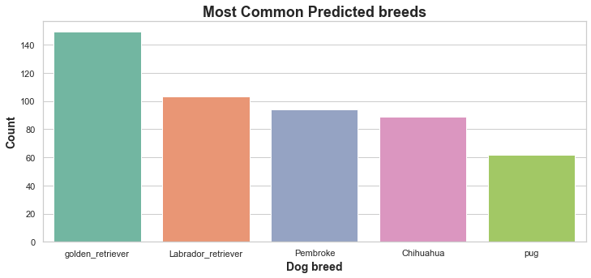

```python
plt.figure(figsize = (12,5))
sns.set_theme(style='whitegrid')
df_breed = df.groupby('predicted_breed', as_index=False)[['tweet_id']].count().sort_values('tweet_id', ascending=False).head(5)
breed_analysis =sns.barplot(
    x = "predicted_breed",
    y= "tweet_id",
    data = df_breed,
    estimator = sum,
    palette= sns.color_palette("Set2"),
    ci = None,

)
plt.title('Most Common Predicted breeds',  fontsize=18, fontweight='bold')
plt.xlabel('Dog breed', fontsize=14, fontweight='bold')
plt.ylabel('Count', fontsize=14, fontweight='bold');
plt.savefig('Most_common_breeds.png')
```

### B) AVERAGE RATING

### Top 5 Breeds by Average Rating

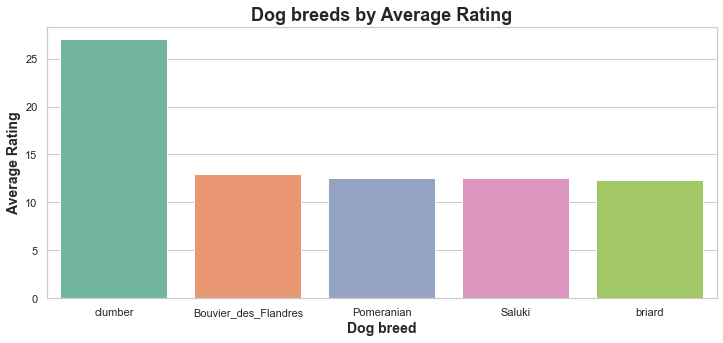

```python
plt.figure(figsize = (12,5))
sns.set_theme(style='whitegrid')
df_breed = df.groupby('predicted_breed', as_index=False)[['rating_numerator']].mean().sort_values(by = 'rating_numerator', ascending=False).head(5)
breed_analysis =sns.barplot(
    x = "predicted_breed",
    y= "rating_numerator",
    data = df_breed,
    estimator = sum,
    palette= sns.color_palette("Set2"),
    ci = None,

)
plt.title('Dog breeds by Average Rating',  fontsize=18, fontweight='bold')
plt.xlabel('Dog breed', fontsize=14, fontweight='bold')
plt.ylabel('Average Rating', fontsize=14, fontweight='bold');
plt.savefig('top_5_breed_rating.png')
```

### Bottom 5 Breeds by Average Rating

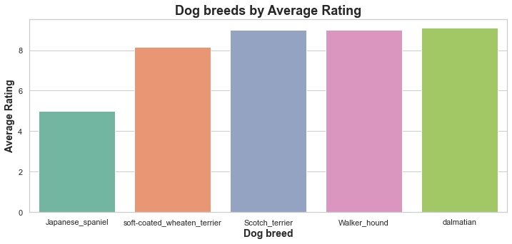

```python
plt.figure(figsize = (12,5))
sns.set_theme(style='whitegrid')
df_breed = df.groupby('predicted_breed', as_index=False)[['rating_numerator']].mean().sort_values(by = 'rating_numerator').head(5)
breed_analysis =sns.barplot(
    x = "predicted_breed",
    y= "rating_numerator",
    data = df_breed,
    estimator = sum,
    palette= sns.color_palette("Set2"),
    ci = None,

)
plt.title('Dog breeds by Average Rating',  fontsize=18, fontweight='bold')
plt.xlabel('Dog breed', fontsize=14, fontweight='bold')
plt.ylabel('Average Rating', fontsize=14, fontweight='bold');
plt.savefig('bottom_5_breed_rating.png')
```

### C) AVERAGE TOTAL ENGAGEMENTS

### Top 5 Breeds by Average Engagements

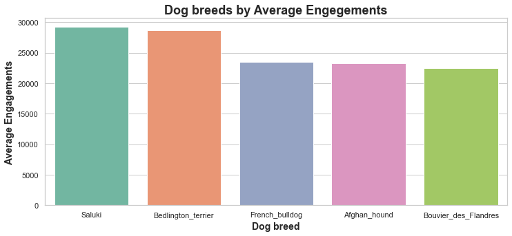

```python
plt.figure(figsize = (12,5))
sns.set_theme(style='whitegrid')
df_breed = df.groupby('predicted_breed', as_index=False)[['total_engagements']].mean().sort_values(by = 'total_engagements', ascending=False).head(5)
breed_analysis =sns.barplot(
    x = "predicted_breed",
    y= "total_engagements",
    data = df_breed,
    estimator = sum,
    palette= sns.color_palette("Set2"),
    ci = None,

)
plt.title('Dog breeds by Average Engegements',  fontsize=18, fontweight='bold')
plt.xlabel('Dog breed', fontsize=14, fontweight='bold')
plt.ylabel('Average Engagements', fontsize=14, fontweight='bold');
plt.savefig('top_5_breeds_engagement.png')
```

### Bottom 5 Breeds by Average Engagements

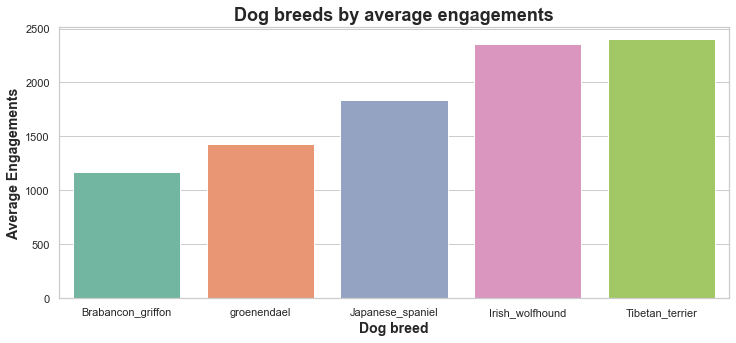

```python
plt.figure(figsize = (12,5))
sns.set_theme(style='whitegrid')
df_breed = df.groupby('predicted_breed', as_index=False)[['total_engagements']].mean().sort_values(by = 'total_engagements').head(5)
breed_analysis =sns.barplot(
    x = "predicted_breed",
    y= "total_engagements",
    data = df_breed,
    estimator = sum,
    palette= sns.color_palette("Set2"),
    ci = None,

)
plt.title('Dog breeds by average engagements',  fontsize=18, fontweight='bold')
plt.xlabel('Dog breed', fontsize=14, fontweight='bold')
plt.ylabel('Average Engagements', fontsize=14, fontweight='bold');
plt.savefig('bottom_5_breed_engagements.png')
```

## 2) Visualization by DOG STAGE

### A) Most Rated Dog Stage

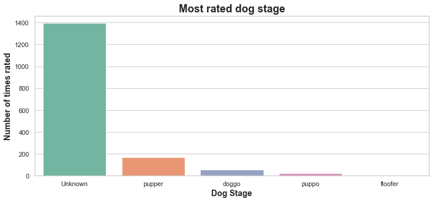

```python
plt.figure(figsize = (12,5))
sns.set_theme(style='whitegrid')
df_stage = df.groupby('dog_stage', as_index=False)[['tweet_id']].count().sort_values(by = 'tweet_id', ascending=False).head(5)
breed_analysis =sns.barplot(
    x = "dog_stage",
    y= "tweet_id",
    data = df_stage,
    estimator = sum,
    palette= sns.color_palette("Set2"),
    ci = None,

)
plt.title('Most rated dog stage',  fontsize=18, fontweight='bold')
plt.xlabel('Dog Stage', fontsize=14, fontweight='bold')
plt.ylabel('Number of times rated', fontsize=14, fontweight='bold');
plt.savefig('most_rated_stage.png')
```

### B) Dog stage by Average Rating

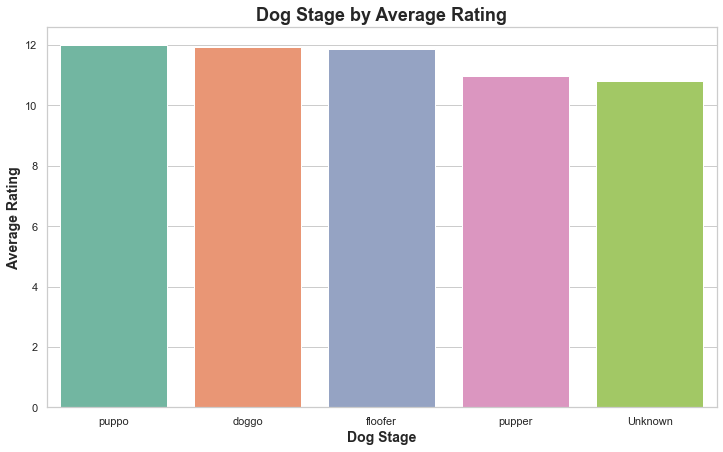

```python
plt.figure(figsize = (12,7))
sns.set_theme(style='whitegrid')
df_breed = df.groupby('dog_stage', as_index=False)[['rating_numerator']].mean().sort_values(by = 'rating_numerator', ascending=False).head(5)
breed_analysis =sns.barplot(
    x = "dog_stage",
    y= "rating_numerator",
    data = df_breed,
    estimator = sum,
    palette= sns.color_palette("Set2"),
    ci = None,

)
plt.title('Dog Stage by Average Rating',  fontsize=18, fontweight='bold')
plt.xlabel('Dog Stage', fontsize=14, fontweight='bold')
plt.ylabel('Average Rating', fontsize=14, fontweight='bold');
plt.savefig('dog_stage_rating.png')
```

### C) Dog stage by Average Engagements

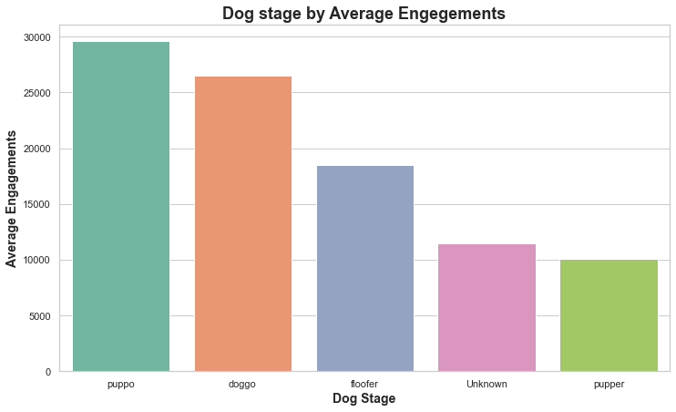

```python
plt.figure(figsize = (12,7))
sns.set_theme(style='whitegrid')
df_breed = df.groupby('dog_stage', as_index=False)[['total_engagements']].mean().sort_values(by = 'total_engagements', ascending=False).head(5)
breed_analysis =sns.barplot(
    x = "dog_stage",
    y= "total_engagements",
    data = df_breed,
    estimator = sum,
    palette= sns.color_palette("Set2"),
    ci = None,

)
plt.title('Dog stage by Average Engegements',  fontsize=18, fontweight='bold')
plt.xlabel('Dog Stage', fontsize=14, fontweight='bold')
plt.ylabel('Average Engagements', fontsize=14, fontweight='bold');
plt.savefig('dog_stage_engagements.png')
```

# CONCLUSION ( Insights Summary )

### Dog Breed

> Golden retriever and labrador retriever are the most rated breeds.

> Clumber breed is the rated breed of dog with the highest average rating.

> Japanese Spaniel is the rated breed of dog with the lowest average raing.

> Saluki and Bedlington terrier are the rated breeds with the highest average engagements.

> Brabancon griffon is the rated breed of dog with the lowest average engagement.

### Dog Stage

> Pupper is the most assigned dog stage.

> Puppo dogs are the dogs with the highest average rating.

> Puppo and doggo are the most loved dog stages by the audience.

# LIMITATIONS

> A lot of dogs were not classified into stages.

> We can't guarantee that the breed predictions are all correct.

> The ratings were exceptionally much for some breeds which will affect the average ratings.